# Applied Logistic Regression HW week 3

Homework Week 3

## Exercise 1:

Use the Myopia Study (MYOPIA.dta) a. Using the results from Week 2, Exercise 1, compute 95 percent confidence intervals for the slope coefficient SPHEQ. Write a sentence interpreting this confidence.

```r
myopia <- read.csv("C:/Users/Karmen/Desktop/All Things Coursera/current/Applied Logistic Regression/1.week 1/MYOPIA-fixed.csv")
logfit <- glm(MYOPIC ~ SPHEQ, data = myopia, family = binomial(link = "logit"))
str(myopia)
```

```
## 'data.frame':    618 obs. of  18 variables:
##  $ ID       : int  1 2 3 4 5 6 7 8 9 10 ...
##  $ STUDYYEAR: int  1992 1995 1991 1990 1995 1995 1993 1991 1991 1991 ...
##  $ MYOPIC   : int  1 0 0 1 0 0 0 0 0 0 ...
##  $ AGE      : int  6 6 6 6 5 6 6 6 7 6 ...
##  $ GENDER   : int  1 1 1 1 0 0 1 1 0 1 ...
##  $ SPHEQ    : num  -0.052 0.608 1.179 0.525 0.697 ...
##  $ AL       : num  21.9 22.4 22.5 22.2 23.3 ...
##  $ ACD      : num  3.69 3.7 3.46 3.86 3.68 ...
##  $ LT       : num  3.5 3.39 3.51 3.61 3.45 ...
##  $ VCD      : num  14.7 15.3 15.5 14.7 16.2 ...
##  $ SPORTHR  : int  45 4 14 18 14 10 12 12 4 30 ...
##  $ READHR   : int  8 0 0 11 0 6 7 0 0 5 ...
##  $ COMPHR   : int  0 1 2 0 0 2 2 0 3 1 ...
##  $ STUDYHR  : int  0 1 0 0 0 1 1 0 1 0 ...
##  $ TVHR     : int  10 7 10 4 4 19 8 8 3 10 ...
##  $ DIOPTERHR: int  34 12 14 37 4 44 36 8 12 27 ...
##  $ MOMMY    : int  1 1 0 0 1 0 0 0 0 0 ...
##  $ DADMY    : int  1 1 0 1 0 1 1 0 0 0 ...
```

```r
(sum_logfit <- summary(logfit))
```

```
##
## Call:
## glm(formula = MYOPIC ~ SPHEQ, family = binomial(link = "logit"),
##     data = myopia)
##
## Deviance Residuals:
##     Min       1Q   Median       3Q      Max
## -1.6435  -0.4533  -0.2681  -0.1029   3.1602
##
## Coefficients:
##             Estimate Std. Error z value Pr(>|z|)
## (Intercept)  0.05397    0.20675   0.261    0.794
## SPHEQ       -3.83310    0.41837  -9.162   <2e-16 ***
## ---
## Signif. codes:  0 '***' 0.001 '**' 0.01 '*' 0.05 '.' 0.1 ' ' 1
##
## (Dispersion parameter for binomial family taken to be 1)
##
##     Null deviance: 480.08  on 617  degrees of freedom
## Residual deviance: 337.34  on 616  degrees of freedom
## AIC: 341.34
##
## Number of Fisher Scoring iterations: 6
```

```r
(coefs <- sum_logfit$coef)
```

```
##                Estimate Std. Error    z value     Pr(>|z|)
## (Intercept)  0.05397314  0.2067483  0.2610572 7.940484e-01
## SPHEQ       -3.83309758  0.4183696 -9.1619878 5.094999e-20
```

```r
#95% confidence interval for the slope of SPHEQ
(ci_SPHEQ <- coefs[2,1] + c(-1,1)*qnorm(0.975, lower = FALSE)*coefs[2,2])
```

```
## [1] -3.013108 -4.653087
```

**Answer:** Logit of a slope for the SPHEQ variable is -3.83310 and 95% confidence interval for it is -4.653087 -3.013108.

2. Use Stata to obtain the estimated covariance matrix. Compute the logit and estimated logistic probability for a subject with SPHEQ = 2. Evaluate the endpoints of the 95 percent confidence intervals for the logit and estimated logistic probability. Write a sentence interpreting the estimated probability and its confidence interval.

```r
#calculating variance-covariance matrix:
(variance_covariance_matrix <- vcov(logfit))
```

```
##             (Intercept)       SPHEQ
## (Intercept)  0.04274486 -0.06337768
## SPHEQ       -0.06337768  0.17503316
```

```r
#calculating logit and probability for subject with SPHEQ = 2:
##logit that subject with SPHEQ = 2 has myopia:
(SPHEQ_2subject_logit <- predict(logfit, newdata = data.frame(SPHEQ = 2), se.fit = TRUE))
```

```
## $fit
##         1
## -7.612222
##
## $se.fit
## [1] 0.6995475
##
## $residual.scale
## [1] 1
```

```r
##probability that subject with SPHEQ = 2 has myopia:
(SPHEQ_2subject_prob <- predict(logfit, newdata = data.frame(SPHEQ = 2), type = "response", se.fit = TRUE))
```

```
## $fit
##            1
## 0.0004941278
##
## $se.fit
##            1
## 0.0003454951
##
## $residual.scale
## [1] 1
```

```r
#confidence interval for the logit for subject with SPHEQ = 2
(ci_SPHEQ_2subject_logit <- SPHEQ_2subject_logit$fit + c(-1,1) * qnorm(0.975, lower = FALSE) * SPHEQ_2subject_logit$se.fit )
```

```
## [1] -6.241134 -8.983310
```

```r
#confidence interval for probability that subject with SPHEQ = 2 has myopia:

##plugging above into formula
(ci_SPHEQ_2subject_prob2 <- exp(ci_SPHEQ_2subject_logit) / (1 + exp(ci_SPHEQ_2subject_logit)))
```

```
## [1] 0.0019438596 0.0001254711
```

```r
##yet another way to calculate the same(probability)
(ci_SPHEQ_2subject_prob <- plogis(ci_SPHEQ_2subject_logit))
```

```
## [1] 0.0019438596 0.0001254711
```

## Exercise 2:

Use the ICU study (icu.dta) a. Using the results from Week 1, Exercise 2, part (d), compute 95 percent confidence intervals for the slope and constant term. Write a sentence interpreting the confidence interval for the slope.

```r
icu <- read.csv("C:/Users/Karmen/Desktop/All Things Coursera/current/Applied Logistic Regression/1.week 1/icu.csv")
str(icu)
```

```
## 'data.frame':    200 obs. of  21 variables:
##  $ ID  : int  552 102 837 863 829 379 247 584 310 906 ...
##  $ STA : int  0 0 0 0 0 0 0 0 0 0 ...
##  $ AGE : int  16 16 17 17 17 18 18 18 18 19 ...
##  $ SEX : int  0 1 1 0 0 0 1 0 0 0 ...
##  $ RACE: int  1 1 3 3 1 1 1 1 1 1 ...
##  $ SER : int  1 0 0 1 1 1 0 1 1 1 ...
##  $ CAN : int  0 0 0 0 0 0 0 1 1 0 ...
##  $ CRN : int  0 0 0 0 0 0 0 0 0 0 ...
##  $ INF : int  0 0 0 0 0 0 0 0 0 1 ...
##  $ CPR : int  0 0 0 0 0 0 0 0 0 0 ...
##  $ SYS : int  100 104 130 136 140 112 146 130 156 100 ...
##  $ HRA : int  140 111 140 78 78 76 112 140 99 137 ...
##  $ PRE : int  0 0 0 0 0 0 0 0 0 0 ...
##  $ TYP : int  1 1 1 1 1 1 1 0 0 1 ...
##  $ FRA : int  1 0 0 0 1 1 0 0 0 0 ...
##  $ PO2 : int  0 0 0 0 0 0 0 0 0 0 ...
##  $ PH  : int  0 0 0 0 0 0 0 0 0 0 ...
##  $ PCO : int  0 0 0 0 0 0 0 0 0 0 ...
##  $ BIC : int  0 0 0 0 0 0 0 0 0 0 ...
##  $ CRE : int  0 0 0 0 0 0 0 0 0 0 ...
##  $ LOC : int  0 0 0 0 0 0 0 0 0 0 ...
```

```r
iculog <- glm(STA ~ AGE, data = icu, family = binomial(link = "logit"))

#table of coefficients and their standard errors:
(coefs <- summary(iculog)$coefficients)
```

```
##                Estimate Std. Error   z value     Pr(>|z|)
## (Intercept) -3.05851323 0.69608124 -4.393903 1.113337e-05
## AGE          0.02754261 0.01056416  2.607174 9.129303e-03
```

```r
#95% CI for the intercept (AKA constant term in STATA):
(ci_intercept <- coefs[1,1] + c(-1,1) * qnorm(0.975, lower = FALSE) * coefs[1, 2])
```

```
## [1] -1.694219 -4.422807
```

```r
#95% CI for the slope of AGE:
(ci_slope_AGE <- coefs[2,1] + c(-1,1) * qnorm(0.975, lower = FALSE) * coefs[2,2])
```

```
## [1] 0.04824799 0.00683723
```

**Answer:** We are 95% sure that logit for the slope for the AGE falls between 0.04824799 and 0.00683723.

2. Obtain the estimated covariance matrix for the model fit from Week 1, Exercise 2, part (d). Compute the logit and estimated logistic probability for a 60-year old subject. Compute a 95 percent confidence intervals for the logit and estimated logistic probability. Write a sentence or two interpreting the estimated probability and its confidence interval.

```r
#variance - covariance matrix
(vcov_icu <- vcov(iculog))
```

```
##              (Intercept)           AGE
## (Intercept)  0.484529087 -0.0071029945
## AGE         -0.007102994  0.0001116015
```

```r
#subject AGE = 60
#logit for CHD for patient AGE = 60
(pt_60_logit <- predict(iculog, newdata = data.frame(AGE = 60), se.fit = TRUE))
```

```
## $fit
##         1
## -1.405957
##
## $se.fit
## [1] 0.1842154
##
## $residual.scale
## [1] 1
```

```r
#probability that patient AGE = 60 has CHD
(pt_60_prob <- predict(iculog, newdata = data.frame(AGE = 60), se.fit = TRUE, type = "response"))
```

```
## $fit
##         1
## 0.1968726
##
## $se.fit
##          1
## 0.02912699
##
## $residual.scale
## [1] 1
```

```r
#95% CI for logit for patient AGE = 60
(ci_ptAge60_logit <- pt_60_logit$fit + c(-1,1) * qnorm(0.975, lower = FALSE) * pt_60_logit$se.fit)
```

```
## [1] -1.044901 -1.767012
```

```r
#95% CI for probability that patient AGE = 60 has CHD
(ci_ptAge60_prob <- pt_60_prob$fit + c(-1,1) * qnorm(0.975, lower = FALSE) * pt_60_prob$se.fit)
```

```
## [1] 0.2539604 0.1397847
```

## Exercise 3:

Use the ICU study (icu.dta) Use the ICU data and consider the multiple logistic regression model of vital status, STA, on age (AGE), cancer part of the present problem (CAN), CPR prior to ICU admission (CPR), infection probable at ICU admission (INF), and race (RACE).

```r
str(icu$RACE)
```

```
##  int [1:200] 1 1 3 3 1 1 1 1 1 1 ...
```

```r
icu$RACE <- as.factor(icu$RACE)
icu_multilog <- glm(STA ~ AGE + CAN + CPR + INF + RACE, data = icu, family = binomial(link = "logit"))
(multi_sum <- summary(icu_multilog))
```

```
##
## Call:
## glm(formula = STA ~ AGE + CAN + CPR + INF + RACE, family = binomial(link = "logit"),
##     data = icu)
##
## Deviance Residuals:
##     Min       1Q   Median       3Q      Max
## -1.3703  -0.6823  -0.5421  -0.3082   2.5124
##
## Coefficients:
##             Estimate Std. Error z value Pr(>|z|)
## (Intercept) -3.51152    0.81443  -4.312 1.62e-05 ***
## AGE          0.02712    0.01159   2.340  0.01926 *
## CAN          0.24451    0.61681   0.396  0.69180
## CPR          1.64650    0.62341   2.641  0.00826 **
## INF          0.68067    0.38042   1.789  0.07357 .
## RACE2       -0.95708    1.08445  -0.883  0.37748
## RACE3        0.25975    0.87127   0.298  0.76561
## ---
## Signif. codes:  0 '***' 0.001 '**' 0.01 '*' 0.05 '.' 0.1 ' ' 1
##
## (Dispersion parameter for binomial family taken to be 1)
##
##     Null deviance: 200.16  on 199  degrees of freedom
## Residual deviance: 179.30  on 193  degrees of freedom
## AIC: 193.3
##
## Number of Fisher Scoring iterations: 5
```

1. The variable RACE is coded at three levels. Prepare a table showing the coding of the two design variables necessary for including this variable in a logistic regression model.

```r
#summary of model object shows that we have 2 dummy variables: RACE2 and RACE3
(coefs <- multi_sum$coef)
```

```
##                Estimate Std. Error    z value     Pr(>|z|)
## (Intercept) -3.51151970 0.81442886 -4.3116347 0.0000162052
## AGE          0.02712074 0.01158785  2.3404454 0.0192607529
## CAN          0.24451057 0.61681460  0.3964085 0.6918036790
## CPR          1.64649699 0.62341312  2.6411010 0.0082637087
## INF          0.68066763 0.38041741  1.7892652 0.0735721155
## RACE2       -0.95707769 1.08445497 -0.8825426 0.3774834642
## RACE3        0.25974927 0.87126813  0.2981278 0.7656056070
```

2. Write down the equation for the logistic regression model of STA on AGE, CAN, CPR, INF, and RACE. Write down the equation for the logit transformation of this logistic regression model. How many parameters does this model contain?

Equation for the logit of regression of STA on AGE, CAN, CPR, INF, and RACE: $logit = \beta_0 + \beta_1 * AGE+ \beta_2 * CAN + \beta_3 * CPR + \beta_4 * INF + \beta_5 * RACE2 + \beta_6 * RACE_3$

Equation for the probability that STA = 1, i.e. that patient admitted to ICU lived to be discharged from hospital:

$P(STA = 1) = \frac{1}{1 + e^{\beta_0 + \beta_1 * AGE+ \beta_2 * CAN + \beta_3 * CPR + \beta_4 * INF + \beta_5 * RACE2 + \beta_6 * RACE3}}$

This model has 6 parameters for predictor variables and 1 parameter for the intercept, 7 parameters in total.

3. Write down an expression for the likelihood and log likelihood for the logistic regression model in part (b). How many likelihood equations are there? Write down an expression for a typical likelihood equation for this problem.

Likelihood function for $\beta$: $\cal l (\beta) = \prod_{i=1}^n \xi(X_i)$

where $\xi(X_i) = \pi(X_i)^{y_i}* [1 - \pi(X_i)]^{1-y_i}$, $X$ is a set of covariates, i.e. predictor variables, and $y_i = 1$ if patient lived to be dicharged from the hospital, and $y_i = 0$ if patient died.  
Log likelihood function may be written as: $\cal L (\beta) = \ln (\ell (\beta)) = \sum_{i=1}^n\{y_i \cdot \ln [\pi(X_i)] - (1 - y_i) \cdot \ln[1 - \pi(X_i)]\}$

There will be $p + 1$ likelihood equations for this problem. They may be expressed as follows:  
for $\beta_0$: $\sum_{i = 1}^n [y_i - \pi(X_i)]$

for $\beta_1$: $\sum_{i = 1}^nX_i \cdot [y_i - \pi(X_i)]$

etc. for the rest of the parameters.

4. Using a logistic regression package, obtain the maximum likelihood estimates of the parameters of the logistic regression model in part (b). Using these estimates write down the equation for the fitted values, that is, the estimated logistic probabilities. **Answer:** When we have created `iculog` model object, the values of the coefficients were obtained as maximum likelihood estimates(`family = binomial(link = "logit")`)

```r
coefs
```

```
##                Estimate Std. Error    z value     Pr(>|z|)
## (Intercept) -3.51151970 0.81442886 -4.3116347 0.0000162052
## AGE          0.02712074 0.01158785  2.3404454 0.0192607529
## CAN          0.24451057 0.61681460  0.3964085 0.6918036790
## CPR          1.64649699 0.62341312  2.6411010 0.0082637087
## INF          0.68066763 0.38041741  1.7892652 0.0735721155
## RACE2       -0.95707769 1.08445497 -0.8825426 0.3774834642
## RACE3        0.25974927 0.87126813  0.2981278 0.7656056070
```

So the equation for the logit transformation is: $g(x)= -3.511 + 0.027 * AGE+ 0.245 * CAN + 1.646 * CPR + 0.681 * INF - 0.957 * RACE2 + 0.259 * RACE3$

And the equation for the logistic regression model is: $\pi(X) = \frac{e^{ -3.511 + 0.027 * AGE+ 0.245 * CAN + 1.646 * CPR + 0.681 * INF - 0.957 * RACE2 + 0.259 * RACE_3}}{1 + e^{ -3.511 + 0.027 * AGE+ 0.245 * CAN + 1.646 * CPR + 0.681 * INF - 0.957 * RACE2 + 0.259 * RACE3}}$

5. Using the results of the output from the logistic regression package used in part (d), assess the significance of the slope coefficients for the variables in the model using the likelihood ratio test. What assumptions are needed for the p-values computed for this test to be valid? What is the value of the deviance for the fitted model?

```r
names(iculog)
```

```
##  [1] "coefficients"      "residuals"         "fitted.values"
##  [4] "effects"           "R"                 "rank"
##  [7] "qr"                "family"            "linear.predictors"
## [10] "deviance"          "aic"               "null.deviance"
## [13] "iter"              "weights"           "prior.weights"
## [16] "df.residual"       "df.null"           "y"
## [19] "converged"         "boundary"          "model"
## [22] "call"              "formula"           "terms"
## [25] "data"              "offset"            "control"
## [28] "method"            "contrasts"         "xlevels"
```

```r
iculog
```

```
##
## Call:  glm(formula = STA ~ AGE, family = binomial(link = "logit"), data = icu)
##
## Coefficients:
## (Intercept)          AGE
##    -3.05851      0.02754
##
## Degrees of Freedom: 199 Total (i.e. Null);  198 Residual
## Null Deviance:       200.2
## Residual Deviance: 192.3     AIC: 196.3
```

```r
names(icu_multilog)
```

```
##  [1] "coefficients"      "residuals"         "fitted.values"
##  [4] "effects"           "R"                 "rank"
##  [7] "qr"                "family"            "linear.predictors"
## [10] "deviance"          "aic"               "null.deviance"
## [13] "iter"              "weights"           "prior.weights"
## [16] "df.residual"       "df.null"           "y"
## [19] "converged"         "boundary"          "model"
## [22] "call"              "formula"           "terms"
## [25] "data"              "offset"            "control"
## [28] "method"            "contrasts"         "xlevels"
```

```r
#likelihood ratio test
(likelihood_ratio_test <- icu_multilog$null.deviance - icu_multilog$deviance)
```

```
## [1] 20.86024
```

```r
#difference in degrees of freedom between naive model and model with 6 parameters (+ 1 for the intercept)
(df.diff <- icu_multilog$df.null - icu_multilog$df.residual)
```

```
## [1] 6
```

```r
(pValueLR <- pchisq(likelihood_ratio_test, df = df.diff, lower.tail = FALSE))
```

```
## [1] 0.001943745
```

```r
#deviance for the fitted model:
icu_multilog$deviance
```

```
## [1] 179.3007
```

Likelihood Ratio Test: A hypothesis test with $H_0: \beta_1\beta_2\beta_3\beta_4\beta_5\beta_6 = 0$ $H_A: At least one of the coefficients is not equal to 0$ G = likelihood ratio test  
D = deviance  
$G = D(model without variable) - D(model with variable)$

Likelihood ratio follows $\chi^2$ distribution with 6 degrees of freedom, i.e. $G \sim \chi^2(6)$. p-value for this likelihood ratio is 0.001943745 which is bellow customary 0.05, hence we can reject null hypothesis claiming that slopes for all predictor variables are no different than zero. To perform likelihood ratio test in the null hypothesis we made assumption that G statistic follows $\chi^2$ distribution with 6 degrees of freedom.  
Deviance for the fitted model, D, is 179.3007.

6. Use the Wald statistics to obtain an approximation to the significance of the individual slope coefficients for the variables in the model.

```r
#a vector of beta values
(betas <- coefs[2:7,1])
```

```
##         AGE         CAN         CPR         INF       RACE2       RACE3
##  0.02712074  0.24451057  1.64649699  0.68066763 -0.95707769  0.25974927
```

```r
#a vector of standard errors for the slopes(betas)
(se.betas <- coefs[2:7, 2])
```

```
##        AGE        CAN        CPR        INF      RACE2      RACE3
## 0.01158785 0.61681460 0.62341312 0.38041741 1.08445497 0.87126813
```

```r
#a vector of calculated Wald test values for each beta
(Walds <- betas/se.betas)
```

```
##        AGE        CAN        CPR        INF      RACE2      RACE3
##  2.3404454  0.3964085  2.6411010  1.7892652 -0.8825426  0.2981278
```

```r
#a vector of p-values for each Wald test
(pvalsW <- ifelse(Walds > 0, 2 * pnorm(Walds, lower = FALSE), 2 * pnorm(Walds)))
```

```
##         AGE         CAN         CPR         INF       RACE2       RACE3
## 0.019260753 0.691803679 0.008263709 0.073572115 0.377483464 0.765605607
```

```r
#pvalsW should have same values as the fourth column of the coefficients table
coefs
```

```
##                Estimate Std. Error    z value     Pr(>|z|)
## (Intercept) -3.51151970 0.81442886 -4.3116347 0.0000162052
## AGE          0.02712074 0.01158785  2.3404454 0.0192607529
## CAN          0.24451057 0.61681460  0.3964085 0.6918036790
## CPR          1.64649699 0.62341312  2.6411010 0.0082637087
## INF          0.68066763 0.38041741  1.7892652 0.0735721155
## RACE2       -0.95707769 1.08445497 -0.8825426 0.3774834642
## RACE3        0.25974927 0.87126813  0.2981278 0.7656056070
```

Fit a reduced model that eliminates those variables with nonsignificant Wald statistics. Assess the joint (conditional) significance of the variables excluded from the model. Present the results of fitting the reduced model in a table.

```r
(icu_multilog_reduced <- glm(STA ~ AGE + CPR + INF, data = icu, family = binomial(link = "logit")))
```

```
##
## Call:  glm(formula = STA ~ AGE + CPR + INF, family = binomial(link = "logit"),
##     data = icu)
##
## Coefficients:
## (Intercept)          AGE          CPR          INF
##    -3.57604      0.02792      1.63066      0.69708
##
## Degrees of Freedom: 199 Total (i.e. Null);  196 Residual
## Null Deviance:       200.2
## Residual Deviance: 180.5     AIC: 188.5
```

```r
(coefs <- summary(icu_multilog_reduced)$coef)
```

```
##                Estimate Std. Error   z value     Pr(>|z|)
## (Intercept) -3.57604481 0.77306043 -4.625828 3.731043e-06
## AGE          0.02792203 0.01135975  2.457979 1.397214e-02
## CPR          1.63066220 0.61553126  2.649195 8.068381e-03
## INF          0.69707644 0.37750003  1.846560 6.481094e-02
```

To compare reduced model with 3 predictors and bigger model with 6 predictors, we can perform likelihood ratio test. It’s a hypothesis test comparing model with 6 predictors and model with 3 predictors. With this test we are assesing the joint (conditional) significance of the variables excluded from the model. $H_0: slopes of variables excluded from the model are all equal to 0.$ $H_A: At least one of the excluded variables has slope that is not zero, hence it is signifficant for predicting response variable$ G = likelihood ratio  
D = deviance  
$G = D(model without variables) - D(model with variables)$ $1.2127 = 180.5134 - 179.3007$

```r
(likelihood_ratio_3x6 <- icu_multilog_reduced$deviance - icu_multilog$deviance)
```

```
## [1] 1.2127
```

```r
(dfs_3x6 <- icu_multilog_reduced$df.residual - icu_multilog$df.residual)
```

```
## [1] 3
```

```r
(pvalueLR_3x6 <- pchisq(likelihood_ratio_3x6, df = dfs_3x6, lower.tail = FALSE))
```

```
## [1] 0.74996
```

Since G statistic follows $\chi^2$ distribution with 3 degrees of freedom, i.e. $G \sim \chi^2 (3)$ we can calculate p-value of likelihood ratio test using `pchisq`. We get p-value of 0.74996, which means that we can’t reject null hypothesis and conclude that the slope of excluded variables is not signifficantly different than 0.  
We excluded variables from the model based on their statistical signifficance evaluated at $\alpha = 5$. Even though p-value for the slope of INF is slightly greater than the $\alpha$ we decided to keep it in the model.

7. Using the results from part (f), compute 95 percent confidence intervals for all coefficients in the model. Write a sentence interpreting the confidence intervals for the non-constant covariates.

```r
coefs
```

```
##                Estimate Std. Error   z value     Pr(>|z|)
## (Intercept) -3.57604481 0.77306043 -4.625828 3.731043e-06
## AGE          0.02792203 0.01135975  2.457979 1.397214e-02
## CPR          1.63066220 0.61553126  2.649195 8.068381e-03
## INF          0.69707644 0.37750003  1.846560 6.481094e-02
```

```r
(betas <- coefs[,1])
```

```
## (Intercept)         AGE         CPR         INF
## -3.57604481  0.02792203  1.63066220  0.69707644
```

```r
(se.betas <- coefs[, 2])
```

```
## (Intercept)         AGE         CPR         INF
##  0.77306043  0.01135975  0.61553126  0.37750003
```

```r
(lower <- betas - qnorm(0.975)*se.betas)
```

```
##  (Intercept)          AGE          CPR          INF
## -5.091215425  0.005657327  0.424243101 -0.042810021
```

```r
(upper <- betas + qnorm(0.975)*se.betas)
```

```
## (Intercept)         AGE         CPR         INF
## -2.06087420  0.05018674  2.83708130  1.43696291
```

```r
(intervals <- data.frame(betas, se.betas, lower, upper))
```

```
##                   betas   se.betas        lower       upper
## (Intercept) -3.57604481 0.77306043 -5.091215425 -2.06087420
## AGE          0.02792203 0.01135975  0.005657327  0.05018674
## CPR          1.63066220 0.61553126  0.424243101  2.83708130
## INF          0.69707644 0.37750003 -0.042810021  1.43696291
```

If we keep INF in the model, these are the results. On the other hand if we exclude INF from the model and fit logisticregreswion model again, the coefficients are slightly different:

```r
(icu_log2predictors <- glm(STA ~ AGE + CPR, data = icu, family = binomial(link = "logit")))
```

```
##
## Call:  glm(formula = STA ~ AGE + CPR, family = binomial(link = "logit"),
##     data = icu)
##
## Coefficients:
## (Intercept)          AGE          CPR
##    -3.35196      0.02961      1.78409
##
## Degrees of Freedom: 199 Total (i.e. Null);  197 Residual
## Null Deviance:       200.2
## Residual Deviance: 184   AIC: 190
```

```r
(coefs2 <- summary(icu_log2predictors)$coef)
```

```
##                Estimate Std. Error   z value     Pr(>|z|)
## (Intercept) -3.35195550 0.74549946 -4.496255 6.916086e-06
## AGE          0.02960741 0.01114894  2.655627 7.916122e-03
## CPR          1.78409209 0.60729714  2.937758 3.305948e-03
```

```r
(betas <- coefs2[,1])
```

```
## (Intercept)         AGE         CPR
## -3.35195550  0.02960741  1.78409209
```

```r
(se.betas <- coefs2[,2])
```

```
## (Intercept)         AGE         CPR
##  0.74549946  0.01114894  0.60729714
```

```r
(lower <- betas - qnorm(0.975)*se.betas)
```

```
##  (Intercept)          AGE          CPR
## -4.813107596  0.007755898  0.593811578
```

```r
(upper <- betas + qnorm(0.975)*se.betas)
```

```
## (Intercept)         AGE         CPR
## -1.89080341  0.05145892  2.97437261
```

```r
(intervals2 <- data.frame(betas, se.betas, lower, upper))
```

```
##                   betas   se.betas        lower       upper
## (Intercept) -3.35195550 0.74549946 -4.813107596 -1.89080341
## AGE          0.02960741 0.01114894  0.007755898  0.05145892
## CPR          1.78409209 0.60729714  0.593811578  2.97437261
```

```r
( noCPR <- predict(icu_log2predictors, newdata = data.frame(AGE = 60, CPR = 0), type = "response"))
```

```
##         1
## 0.1714322
```

```r
yesCPR <- predict(icu_log2predictors, newdata = data.frame(AGE = 60, CPR = 1), type = "response")
```

If we set up a vector of ages for hypothetical patients, from 15 to 90 and compare their probabilities of being alive at the moment of discharge from the hospital:

```r
(ages <- seq(15, 90,5))
```

```
##  [1] 15 20 25 30 35 40 45 50 55 60 65 70 75 80 85 90
```

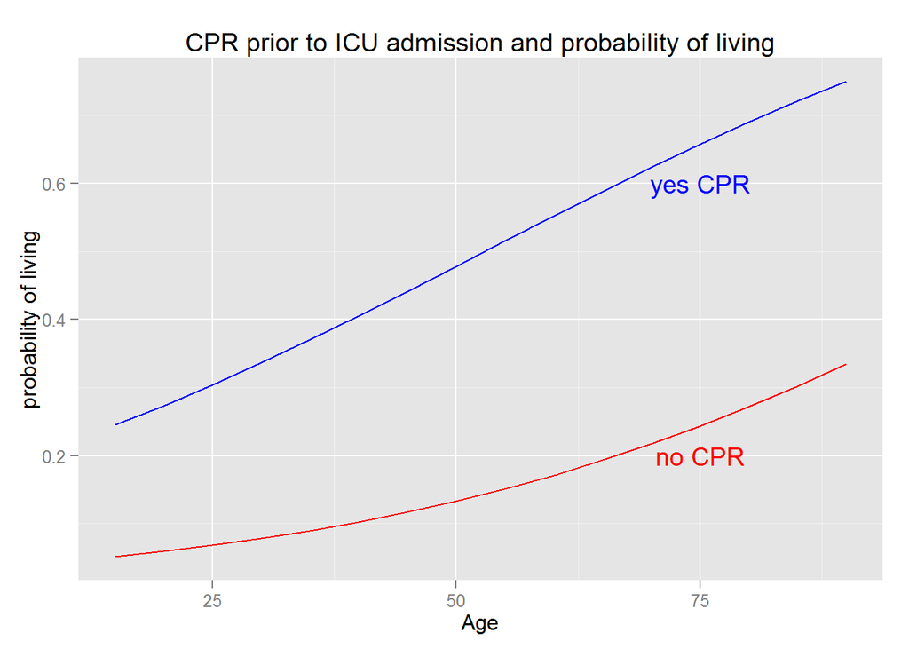

```r
hyp_cpr1 <- data.frame(AGE = ages, CPR = 1)
pred_cpr1 <- predict(icu_log2predictors, newdata = hyp_cpr1, type = "response")

hyp_cpr0 <- data.frame(AGE = ages, CPR = 0)
pred_cpr0 <- predict(icu_log2predictors, newdata = hyp_cpr0, type = "response")

hypothetical <- data.frame(AGE = ages, if_noCPR = pred_cpr0, if_yesCPR = pred_cpr1)

library(ggplot2)

ggplot()   +
  geom_line(data = hypothetical, aes(x = AGE, y = if_noCPR), color = "red")  +
  geom_line(data = hypothetical, aes(x = AGE, y = if_yesCPR), color = "blue") +
  annotate("text", x = 75, y = 0.6, label = "yes CPR", color = "blue")  +
  annotate("text", x = 75, y = 0.2, label = "no CPR", color = "red") +
  labs(x = "Age", y = "probability of living")  +
  ggtitle("CPR prior to ICU admission and probability of living")
```

```r
dim(icu)
```

```
## [1] 200  21
```

```r
factorSTA <- as.factor(icu$STA)
levels(factorSTA) <- c("0 = dead", "1 = alive")
levels(factorSTA)
```

```
## [1] "0 = dead"  "1 = alive"
```

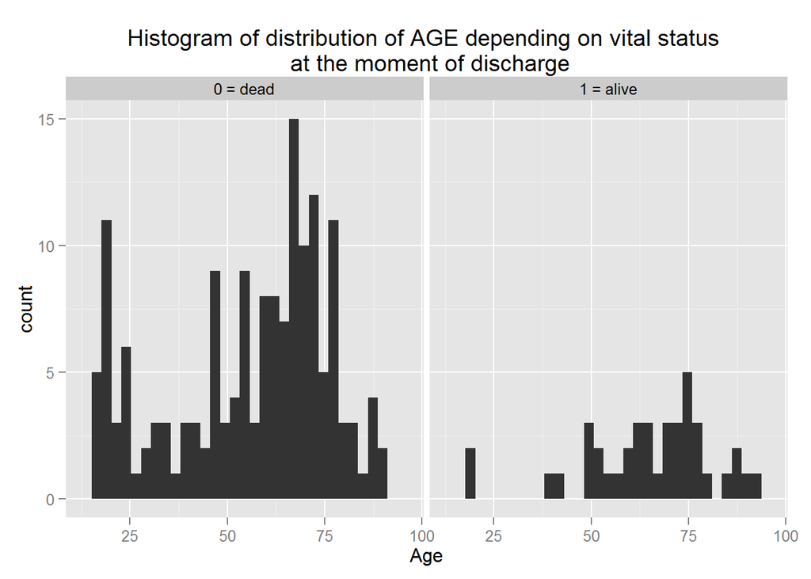

```r
icu$factorSTA <- factorSTA

ggplot(data = icu, aes(x = AGE))  +
  geom_histogram()   +
  facet_wrap(~factorSTA)   +
  labs(x = "Age")  +
  ggtitle("Histogram of distribution of AGE depending on vital status \n at the moment of discharge")
```

From line plot we could conclude that young people are more likely to die than the old people, which is counterintuitive with the fact that younger people recover more easily than the old people. However, it should be taken into consideration the etiology of the medical condition that brings different age groups into intensive care unit, and their effect on survival rates. Also, there is only 200 cases in the dataset, which is also something that should be taken into account.